# Chapter 1: Picturing Distributions with Graphs

Corinne Riddell

September 1, 2021

# Learning objectives for today:

1. Link textbook terminology to R terminology
2. What are the four types of variables?
3. Visualization of categorical data: use `ggplot`’s `geom_bar()`
4. Visualization of continuous data: use `ggplot`’s `geom_histogram()`
5. Describe distributions based on their shape, center, and spread.

# Readings

- Chapter 1 of Baldi and Moore
- General `ggplot` R code Resources
  - [`geom_bar()`](https://moderndive.com/2-viz.html#geombar)(See 2.8.1)
  - [`geom_histogram()`](https://moderndive.com/2-viz.html#histograms)(2.5.1-2.5.2)

# Types of variables

- **Categorical** variable: A variable that has grouping levels. Mathematically you can calculate the proportion (%) of individuals in each level of the category.
  - **Nominal** variables: have no underlying order or rank. E.g., hospital ID, HIV status (yes/no variables)
  - **Ordinal** variables: can be ordered or ranked. E.g., socio-economic status
- **Quantitative** variable: A continuous, numeric variable that you can perform mathematical operations on. Mathematically, we can you take the median or average of these variables
  - **Discrete** variables: can be counted. E.g., number of brain lesions
  - **Continuous** variables: can be measured precisely, with a ruler or scale. E.g, blood alcohol content, gestational age at birth

# Examples

Categorize each variable as nominal, ordinal, discrete, or continuous:

- `BMI category`:
- `Race`:
- `Income`:
- `Number of previous births`:

# Examples

Categorize each variable as nominal, ordinal, discrete, or continuous:

- `BMI category`: ordinal - there is an underlying order to this categorical variable
- `Race`:
- `Income`:
- `Number of previous births`:

# Examples

Categorize each variable as nominal, ordinal, discrete, or continuous:

- `BMI category`: ordinal - there is an underlying order to this categorical variable
- `Race`: nominal - no underlying order to racial categories.
- `Income`:
- `Number of previous births`:

# Examples

Categorize each variable as nominal, ordinal, discrete, or continuous:

- `BMI category`: ordinal - there is an underlying order to this categorical variable
- `Race`: nominal - no underlying order to racial categories.
- `Income`: continuous variable - can measure income to the nearest dollar or cent
- `Number of previous births`:

# Examples

Categorize each variable as nominal, ordinal, discrete, or continuous:

- `BMI category`: ordinal - there is an underlying order to this categorical variable
- `Race`: nominal - no underlying order to racial categories.
- `Income`: continuous variable - can measure income to the nearest dollar or cent
- `Number of previous births`: discrete - can count the number of previous births a person has

# Visualization of categorical data

- What is the best way to visualize one categorical variable at a time?

# Visualization of categorical data

- Generally speaking, **it is not a good idea to use pie charts**
  - Difficult to judge the area of the smallest slices
  - Areas of the smallest (largest) slices are under-judged (over-judged)
- We will not use pie charts in this class (except when looking at the output from Google forms!!)

# Visualization of categorical data

- We prefer **bar graphs** (also called **bar charts**) for the display of categorical data.
- Bar charts display the number or percent of data for each level of the categorical variable being plotted

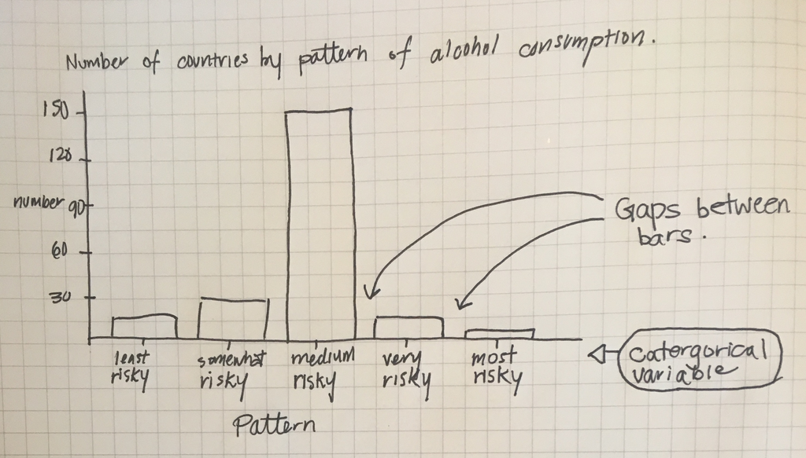

# An example using infectious disease data

- Task: Make a bar chart of the percent of cases on infectious disease for each category of disease.
- First, read and view the infectious disease data from Baldi and Moore:

```r
id_data <- read_csv("./data/Ch01_ID-data.csv")
id_data
```

```
## # A tibble: 7 x 4
##   disease            type      number_cases percent_cases
##   <chr>              <chr>            <dbl>         <dbl>
## 1 Chlamydia          STI             174557         66.4
## 2 Gonorrhea          STI              44974         17.1
## 3 Pertussis          Pertussis        11219          4.27
## 4 Campylobacteriosis Foodborne         7919          3.01
## 5 Early syphilis     STI               7191          2.74
## 6 Salmonellosis      Foodborne         5361          2.04
## 7 Other              Other            11559          4.40
```

# An example using infectious disease data

- Note the variables `number_cases` and `percent_cases`
- What do you want the bar chart to display? What is the `x` and `y` variables for a bar chart?
- What `geom_` should we use? (It is one we have not learnt yet)

# `ggplot`’s `geom_bar()` makes a bar chart

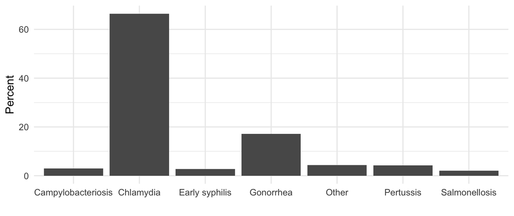

```r
ggplot(id_data, aes(x = disease, y = percent_cases)) +
  geom_bar(stat = "identity") +
  labs(y = "Percent", x = "") +
  theme_minimal(base_size = 15)
```

- `stat = "identity"` tells geom_bar that we supplied a y variable that is exactly what we want to plot. We do not need geom_bar() to calculate the number or percent for us.
- `base_size` controls the font size on these plots
- `theme_minimal()` affects the “look” of the plot. It removes the grey background and adds grey gridlines

# `fct_reorder` reorders `disease` according to value of `percent_cases`

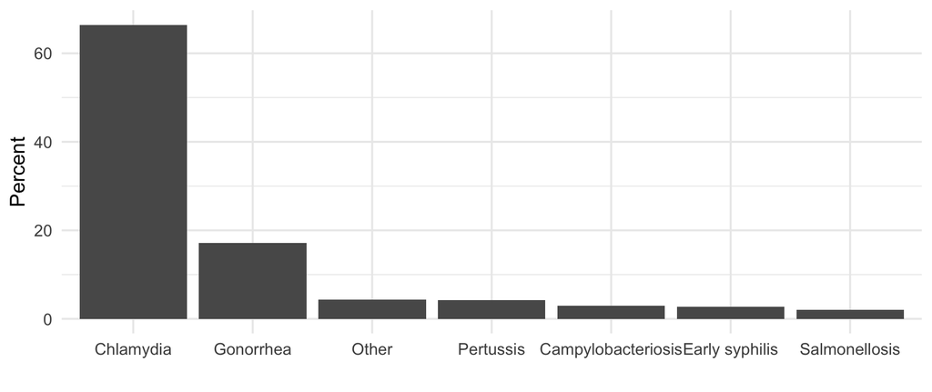

```r
id_data <- id_data %>%
  mutate(disease_ordered = fct_reorder(disease, percent_cases, .desc = T))

ggplot(id_data, aes(x = disease_ordered, y = percent_cases)) +
  geom_bar(stat = "identity") +
  labs(y = "Percent", x = "") +
  theme_minimal(base_size = 15)
```

# Use `aes(fill = type)` to link the bar’s fill to the disease type

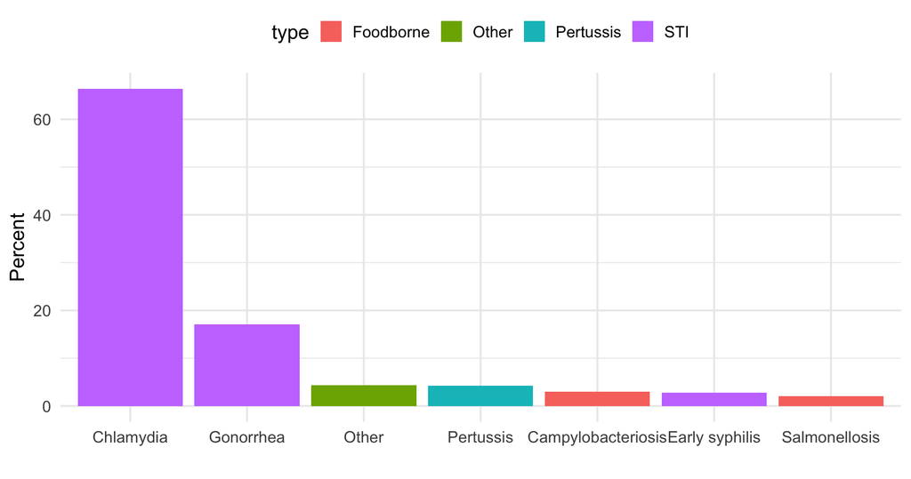

```r
ggplot(id_data, aes(x = disease_ordered, y = percent_cases)) +
  geom_bar(stat = "identity", aes(fill = type)) +
  labs(y = "Percent", x = "") +
  theme_minimal(base_size = 15) +
  theme(legend.position = "top")
```

- Why do we use `fill` not `col` to shade the bars?

# Visualization of quantitative data

- Histograms look a lot like bar charts, except that the bars touch because the underlying scale is numeric.
- In order to make a histogram, the underlying data needs to be **binned** into categories and the number or percent of data in each category becomes the height of each bar.

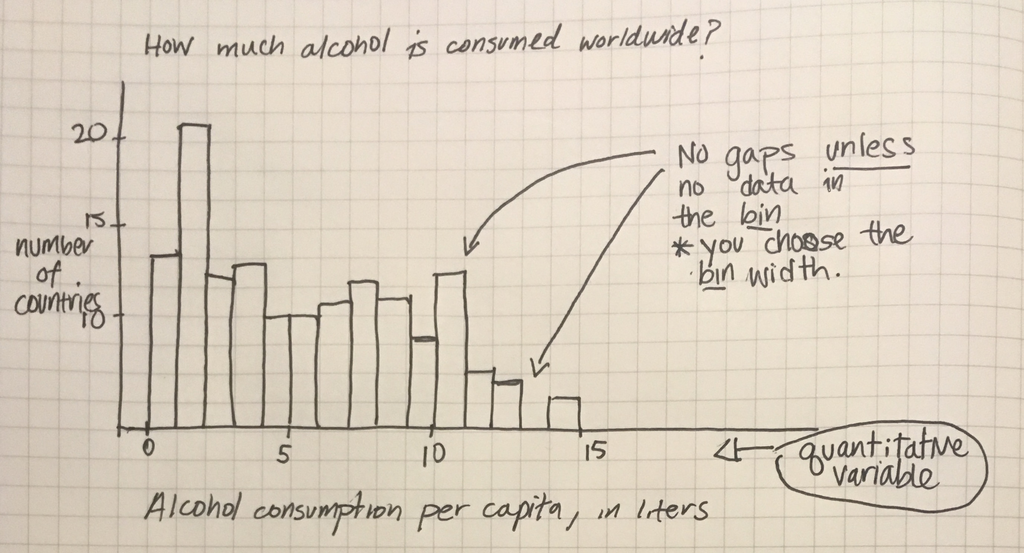

# Example of opioid state prescription rates

- The data folder contains updated data from 2018. It came from the paper: “Opioid Prescribing Rates by Congressional Districts, United States, 2016”, by Rolheiser et al. [link](https://ajph.aphapublications.org/doi/10.2105/AJPH.2018.304532)

# Example of opioid state prescription rates

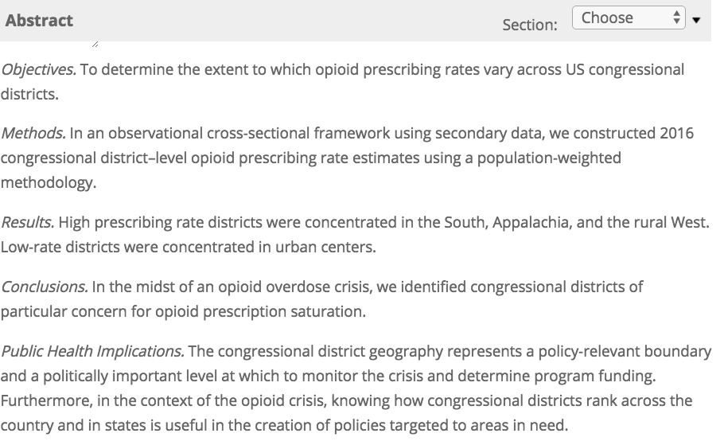

# Example of opioid state prescription rates

```r
opi_data <- read_csv("./data/Ch01_opioid-data.csv")
head(opi_data)
```

```
## # A tibble: 6 x 8
##    Rank State  Mean Median    SD   Min   Max Num_Districts
##   <dbl> <chr> <dbl>  <dbl> <dbl> <dbl> <dbl>         <dbl>
## 1     1 AL    121.   113.  21.9  106.   167.             7
## 2     2 AR    115.   115.   8.59 105.   126.             4
## 3     3 TN    108.   108.  19.2   73.6  133              9
## 4     4 MS    106.   106.  17.4   83.9  126.             4
## 5     5 LA     98.4   98.9 10.3   83.2  113.             6
## 6     6 KY     98.1   85.8 26.7   77.6  147              6
```

- `Mean` provides the mean prescribing rate per 100 individuals. Thus, a mean of 121.31 implies that in Alabama, there were 121.31 opioid prescriptions per 100 persons, an average across the 7 congressional districts.

# Histogram of opioid prescription rates

- Task: Make a histogram of the average prescribing rates across US states
- What is the x variable? What is the y variable?
- What `geom` should be used?

# Histogram of opioid prescription rates

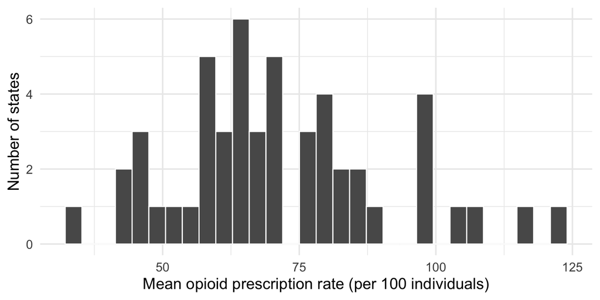

```r
ggplot(data = opi_data, aes(x = Mean)) +
  geom_histogram(col = "white") +
  labs(x = "Mean opioid prescription rate (per 100 individuals)",
       y = "Number of states") +
  theme_minimal(base_size = 15)
```

- Remember: the default number of bins is 30. R prints a message about this and reminds us to pick a `binwidth` instead.
- The `binwidth` is the number of units according to the x axis that each bin covers.
- Try making plots of different binwidths to see how it affects the display of data

# `geom_histogram(binwidth = 5)`

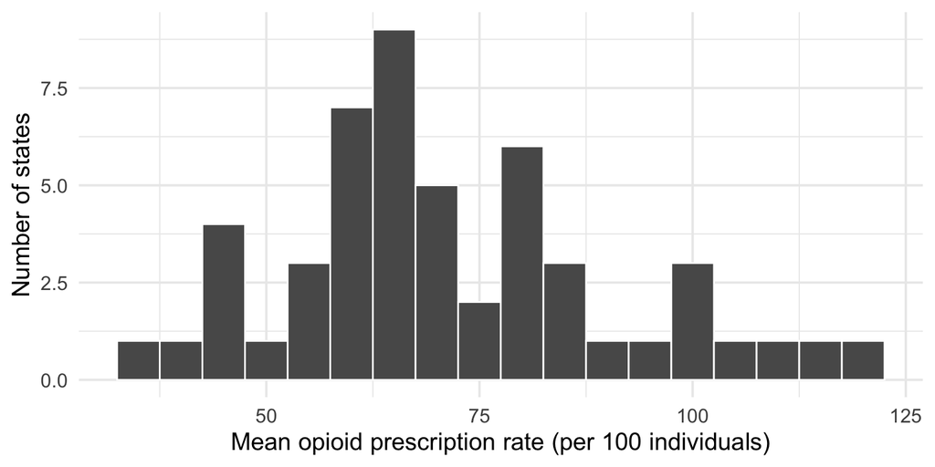

```r
ggplot(data = opi_data, aes(x = Mean)) +
  geom_histogram(col = "white", binwidth = 5) +
  labs(x = "Mean opioid prescription rate (per 100 individuals)",
       y = "Number of states") +
  theme_minimal(base_size = 15)
```

# `geom_histogram(binwidth = 10)`

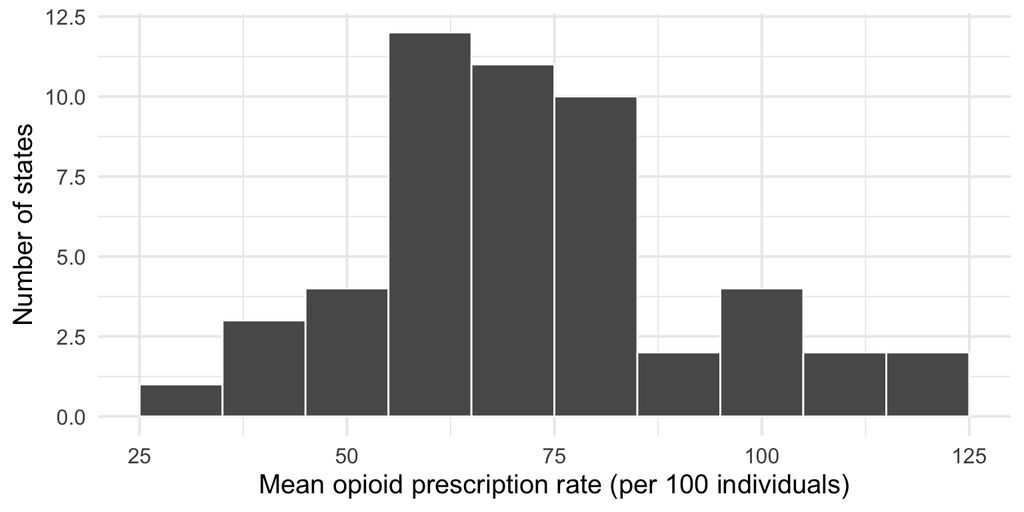

```r
ggplot(data = opi_data, aes(x = Mean)) +
  geom_histogram(col = "white", binwidth = 10) +
  labs(x = "Mean opioid prescription rate (per 100 individuals)",
       y = "Number of states") +
  theme_minimal(base_size = 15)
```

# Shape, Center, Spread

- When we examine histograms, we can make comments on a distribution’s:
  - **Shape**: Is the distribution **symmetric** or **skewed** to the left or right? Be careful! People often confused distributions that are skewed left with skewed right and vice versa.
  - **Center**: Does the histogram have one peak (unimodal), or two (bimodal) or more?
  - **Spread**: How spread out are the values? What is the range of the data?
  - **Outliers**: Do any of the measurements fall outside of the range of most of the data points?

# Is this skewed left or skewed right?

[figure not shown]

# Visualize quantitative variables over time using time plots

- **Time plots** are a specific subset of line plots where the x variable is time.
- Unlike the previous plots discussed today, the time plot shows a relationship between two variables:
  1. a quantitative variable
  2. time
- Often, these plots are used to look for cycles (e.g., seasonal patterns that recur each year) or trends (e.g., overall increases or decreases seen over time).
- The life expectancy trends we plotted last lecture are time plots.

# Recap: What new functions did we use?

1. `geom_bar(stat = "identity")` to make a bar chart when you specify the y variable
2. `geom_histogram()` to make a histogram for which ggplot needs to calculate the count
3. `fct_reorder(var1, var2)` to reorder a categorical variable (`var1`) by a numeric variable (`var2`)
   - from the `forcats` package